# Ecuacion de ds y s para estimar probabilidades empiricas

Rolando Fortanell

2025-02-18

Vamos a simular el comportamiento del precio de un activo que esta determinado por la ecuación

$$dS=0.25Sdt+0.15SdW$$

Con parametros anuales con valor inicial de 10. Usaremos este comportamiento para determinar probabilidades sobre el precio, lo primero que necesito es determinar quien es S, que sigue el comportamiento descrito por la ecuación ds.

Para determinar S, usamos el lema de ITO y obtenemos:

$$S_{t+1}=S_t
e^{(0.25-\frac{1}{2}0.15^2)dt+0.15 dw}$$

Usaremos la ecuación para generar simulaciones y obtener lo siguiente:

Precio Esperado para dentro de un año Probabilidad de que el precio sea mayor a 10 en un año Probabilidad de que el precio supere 12 en una año Probabilidad de que el precio se ubique entre 11 y 13 en un año Intervalo de confianza para el precio en un año al 90%

```r
set.seed(123)
So <- 10
mu <- 0.25
sigma <- 0.15
T <- 1 #El tiempo se escribe em años. utilizamos 1 porque vamos a predecir dentro de un año
dt <- T/252 #Se divide entre 252 para poder ver la simulacion completa aunque el unico punto que nos importa es el final
t <- seq(0,T,length.out=252)
```

Vamos a simular dw, el proceso de Wiener

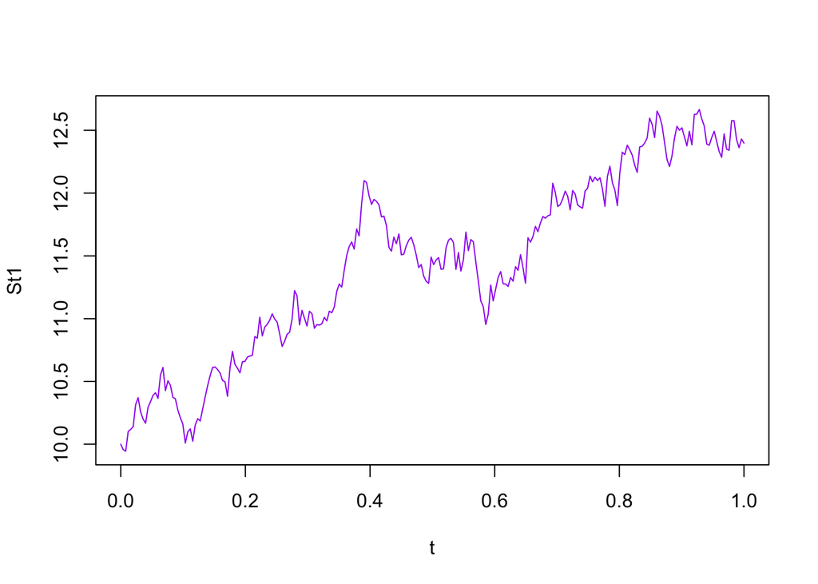

```r
W <- c(0,cumsum(sqrt(dt)*rnorm(251)))
St1 <- So*exp((mu-.5*sigma^2)*t+sigma*W)
plot(t,St1, type="l", col='purple')
```

Vamos a hacer multiples simulaciones de este comportamiento

```r
sim <- 1000000
p_final <- numeric(sim) # aqui vamos a guardar el precio final, el cual correspondel al precio anual de cada simulacion

for(i in 1:sim){
  W <- c(0,cumsum(sqrt(dt)*rnorm(251)))
  St1 <- So*exp((mu-.5*sigma^2)*t+sigma*W)
  p_final[i] <- St1[252]
}
```

La distribucion de probabilidad del precio para dentro de un año con un millon de simuaciones es;

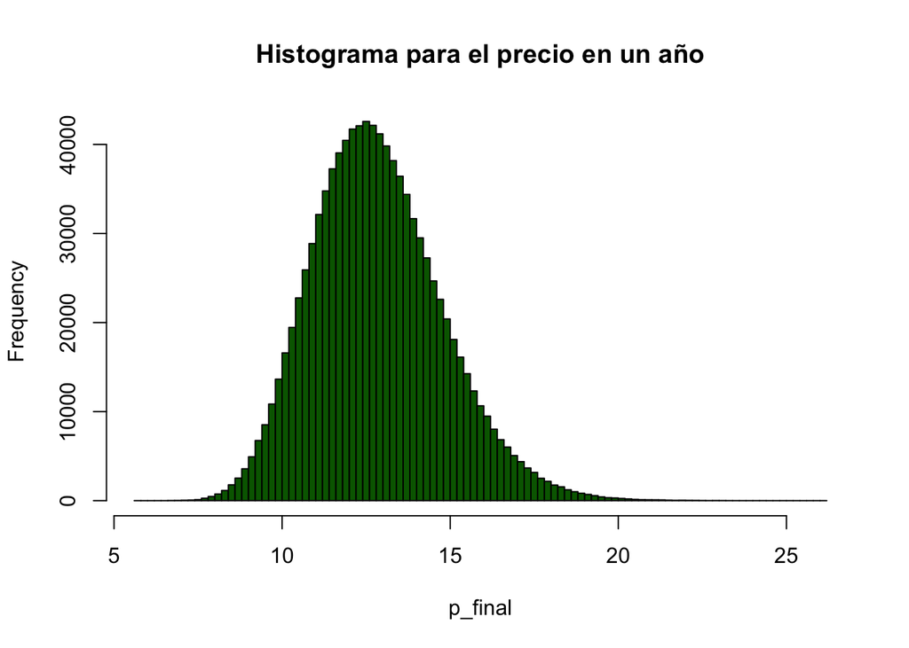

```r
hist(p_final, n=100, col="darkgreen", main="Histograma para el precio en un año")
```

Precio esperado:

```r
mean(p_final)
```

```
## [1] 12.84015
```

Probabilidad de qu el precio sea mayor a 10 en un año

```r
mean(p_final>10)
```

```
## [1] 0.944551
```

Probabilidad mayor a 12 en un año

```r
mean(p_final>12)
```

```
## [1] 0.64729
```

Que se ubique entre 11 y 13

```r
mean(p_final<13 & p_final>11)
```

```
## [1] 0.393403
```

Calcular un intervalo de confianza al 90% para el precio dentro de un año

```r
quantile(p_final, 0.05)
```

```
##     5%
## 9.9267
```

```r
quantile(p_final, 0.95)
```

```
##      95%
## 16.23997
```

## Actividad:

### Bajar el precio de un activo que no cotice en la BMV y vas a usar el ultimo año de informacion para calcular mu y sigma y con eso, vas a determinar la probabilidad de que el precio incremente un 30$ de su valor actual a un año.

```r
library(quantmod)
library(lubridate)
clave <- "AMZN"
datos <- new.env()
getSymbols(clave, from=today() - years(1),to=today(), env=datos)
```

```
## [1] "AMZN"
```

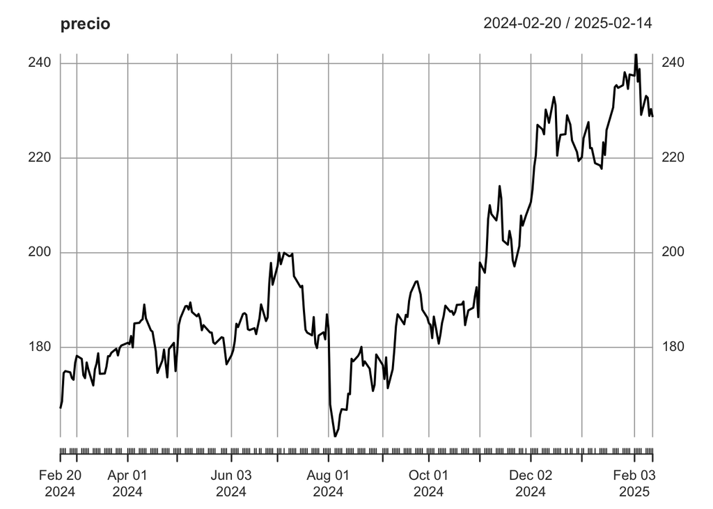

```r
precio<- datos[[clave]][,6]
rendimiento <- na.omit(diff(log(precio)))
plot(precio)
```

### Definir parametros

```r
mu <- mean(rendimiento)*252
sigma <- sd(rendimiento)*sqrt(252)
So <- as.numeric(tail(precio,1))
T <- 1
dt <- T/252
t <- seq(0,T,length.out=252)

mu
```

```
## [1] 0.318913
```

```r
sigma
```

```
## [1] 0.274636
```

```r
So
```

```
## [1] 228.68
```

### Simulacion

```r
sim <- 1000000
p_final <- numeric(sim)

for(i in 1:sim){
  W <- c(0,cumsum(sqrt(dt)*rnorm(251)))
  St1 <- So*exp((mu-.5*sigma^2)*t+sigma*W)
  p_final[i] <- St1[252]
}
```

### Probabilidad de que el precio inicial sea mayor al 30%

```r
mean(p_final>So*1.3)
```

```
## [1] 0.526991
```